# Airbnb Project

# Data Exploration

First, let’s load and explore the AirBnB data (Paris data).

```r
library(readr)
library(dplyr)
```

```r
library(shiny)
library(ggplot2)
library("lubridate")
```

Load the AirBnB data

```r
airbnb_data <-load("C:/Users/Nopchanok/OneDrive/Desktop/DSTI/R/Project R/AirBnB (1).Rdata")
```

```r
head(airbnb_data)
```

```
## [1] "L" "R"
```

```r
dim(L)
```

```
## [1] 52725    95
```

```r
dim(R)
```

```
## [1] 663599      2
```

```r
colnames(L)
```

```
##  [1] "id"                               "listing_url"
##  [3] "scrape_id"                        "last_scraped"
##  [5] "name"                             "summary"
##  [7] "space"                            "description"
##  [9] "experiences_offered"              "neighborhood_overview"
## [11] "notes"                            "transit"
## [13] "access"                           "interaction"
## [15] "house_rules"                      "thumbnail_url"
## [17] "medium_url"                       "picture_url"
## [19] "xl_picture_url"                   "host_id"
## [21] "host_url"                         "host_name"
## [23] "host_since"                       "host_location"
## [25] "host_about"                       "host_response_time"
## [27] "host_response_rate"               "host_acceptance_rate"
## [29] "host_is_superhost"                "host_thumbnail_url"
```

[output cut: 33 more lines]

```r
colnames(R)
```

```
## [1] "listing_id" "date"
```

The AirBnB data set has two different tables named L and R:

- The table “L” contains 95 variables
- The table “R” contains only two variables.

# Cleaning the dataset

For our analysis we will use few columns and will drop other columns in the cleaning data process:

```r
New_data <- select(L, id, host_id, host_name, host_is_superhost, neighbourhood, city, zipcode, country_code, latitude, longitude, property_type, room_type, accommodates, bathrooms, bedrooms, beds, bed_type, amenities, price, weekly_price, monthly_price, minimum_nights, maximum_nights, calculated_host_listings_count)
```

```r
colnames(New_data)
```

```
##  [1] "id"                             "host_id"
##  [3] "host_name"                      "host_is_superhost"
##  [5] "neighbourhood"                  "city"
##  [7] "zipcode"                        "country_code"
##  [9] "latitude"                       "longitude"
## [11] "property_type"                  "room_type"
## [13] "accommodates"                   "bathrooms"
## [15] "bedrooms"                       "beds"
## [17] "bed_type"                       "amenities"
## [19] "price"                          "weekly_price"
## [21] "monthly_price"                  "minimum_nights"
## [23] "maximum_nights"                 "calculated_host_listings_count"
```

```r
dim(New_data)
```

```
## [1] 52725    24
```

Checking NA values and if we need to impute them

```r
table(is.na(New_data))
```

```
##
##   FALSE    TRUE
## 1264884     516
```

Checking NA values per column

```r
colSums(is.na(New_data))
```

```
##                             id                        host_id
##                              0                              0
##                      host_name              host_is_superhost
##                              0                              0
##                  neighbourhood                           city
##                              0                              0
##                        zipcode                   country_code
##                              0                              0
##                       latitude                      longitude
##                              0                              0
##                  property_type                      room_type
##                              0                              0
##                   accommodates                      bathrooms
##                              0                            243
##                       bedrooms                           beds
##                            193                             80
##                       bed_type                      amenities
##                              0                              0
##                          price                   weekly_price
##                              0                              0
##                  monthly_price                 minimum_nights
##                              0                              0
##                 maximum_nights calculated_host_listings_count
##                              0                              0
```

For each variable, we replaced the missing values by the mean of the corresponding column.

```r
## Bathrooms
a = mean(New_data$bathrooms,na.rm = TRUE)
sel = is.na(New_data$bathrooms)
New_data$bathrooms[sel] = a

## Bedrooms
b = mean(New_data$bedrooms,na.rm = TRUE)
sel = is.na(New_data$bedrooms)
New_data$bedrooms[sel] = b

##Beds
c = mean(New_data$beds,na.rm = TRUE)
sel = is.na(New_data$beds)
New_data$beds[sel] = c
```

```r
colSums(is.na(New_data))
```

```
##                             id                        host_id
##                              0                              0
##                      host_name              host_is_superhost
##                              0                              0
##                  neighbourhood                           city
##                              0                              0
##                        zipcode                   country_code
##                              0                              0
##                       latitude                      longitude
##                              0                              0
##                  property_type                      room_type
##                              0                              0
##                   accommodates                      bathrooms
##                              0                              0
##                       bedrooms                           beds
##                              0                              0
##                       bed_type                      amenities
##                              0                              0
##                          price                   weekly_price
##                              0                              0
##                  monthly_price                 minimum_nights
##                              0                              0
##                 maximum_nights calculated_host_listings_count
##                              0                              0
```

# Analyze Data

##Relationship between prices and apartment feature

```r
pricefeature <- select(L, id, property_type, bathrooms, bed_type, price, host_is_superhost, room_type, bedrooms, weekly_price, neighbourhood, city, beds, monthly_price, latitude, minimum_nights)
pricefeature$priceformatted <- as.numeric(gsub("\\$", "",pricefeature$price))
```

Imputing NA values

```r
for (j in 1:ncol(pricefeature)){
  sel = is.na(pricefeature[,j])
  pricefeature[sel,j] = mean(pricefeature[,j],na.rm=TRUE)
}
```

Converting float values of bedroooms to int

```r
pricefeature$bedrooms <- as.integer(pricefeature$bedrooms)
table(pricefeature$bedrooms)
```

```
##
##     0     1     2     3     4     5     6     7     9    10
## 10516 31945  7629  2069   460    84    17     2     1     2
```

-Price by Property type

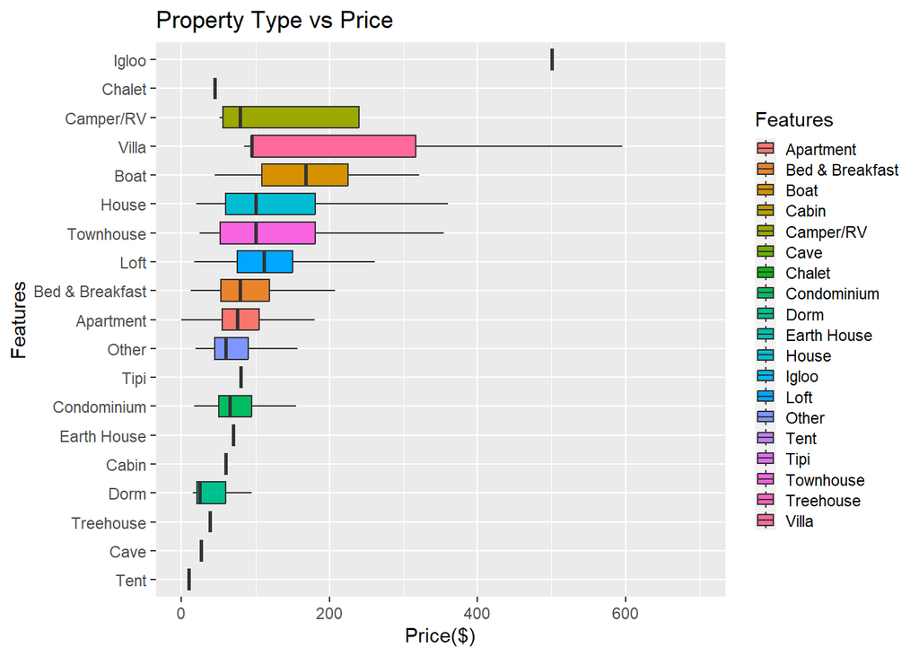

```r
pricefeature <- pricefeature %>% mutate(property_type = replace(property_type, property_type == "", "Other"))
ggplot(pricefeature, aes(x=reorder(property_type, priceformatted), y=priceformatted, fill=property_type) ) +
geom_boxplot(outlier.shape = NA) + coord_flip() + theme(legend.key.size = unit(0.4, 'cm')) +labs(title= "Property Type vs Price", y="Price($)", x = "Features", fill = "Features") + scale_y_continuous(limits = c(0,700))
```

- Price by Room type

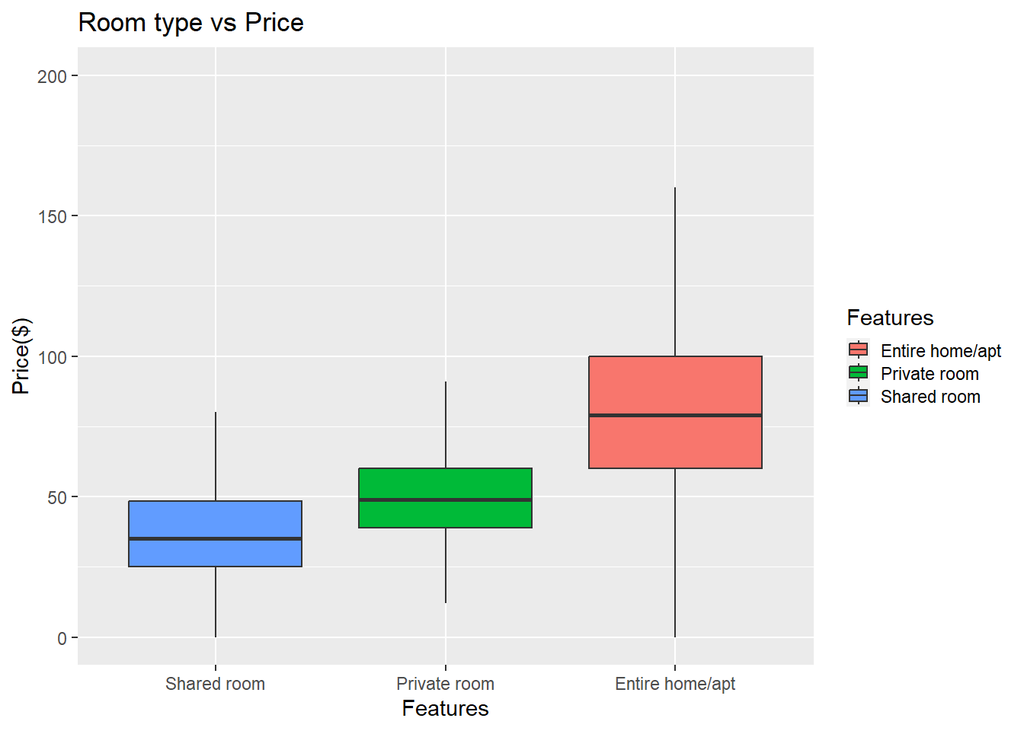

```r
ggplot(pricefeature, aes(x=reorder(room_type, priceformatted), y=priceformatted, fill=room_type) ) +
geom_boxplot(outlier.shape = NA) + theme(legend.key.size = unit(0.4, 'cm')) + labs(title= "Room type vs Price", y="Price($)", x = "Features", fill = "Features") + scale_y_continuous(limits = c(0,200))
```

Convertir bedrooms column to factor to plot.

```r
pricefeature$bedrooms <- as.factor(pricefeature$bedrooms)
```

- Price by Bedrooms quantity

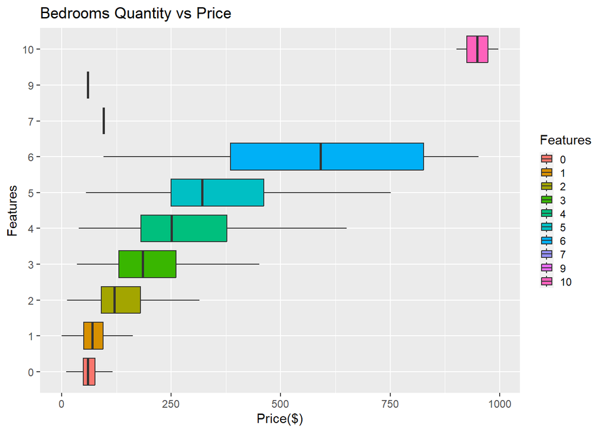

```r
ggplot(pricefeature, aes(x=bedrooms, y=priceformatted, fill=bedrooms) ) +
geom_boxplot(outlier.shape = NA) + coord_flip() + theme(legend.key.size = unit(0.4, 'cm')) + labs(title= "Bedrooms Quantity vs Price", y="Price($)", x = "Features", fill = "Features")
```